# Mouse in vitro thyroid scRNA-seq analysis

Romitti, Eski et al., 2021

Sema Elif Eski

2021-04-17

[Romitti, Eski et al., 2021 (doi: 10.1101/2021.01.18.427103)](https://www.biorxiv.org/content/10.1101/2021.01.18.427103v1)

Load the packages

```r
library(Seurat)
library(dplyr)
library(Matrix)
library(ggpubr)
library(gplots)
library(readr)
```

## Prepare the data

```r
# clear workspace
rm(list = ls())

# Load the data
rawdata <- Read10X(data.dir = "/home/zebrafish/Elif/Singhlab/SC-Data/Mouse_BFX1208/filtered_feature_bc_matrix/")
MmThyroid <- CreateSeuratObject(counts = rawdata,
                                project = "10X Project",
                                min.cells = 3, min.features = 200,
                                names.field = 2, names.delim = "-")
rm(rawdata)
```

```r
MmThyroid
```

```
## An object of class Seurat
## 18636 features across 9904 samples within 1 assay
## Active assay: RNA (18636 features, 0 variable features)
```

**Quality Control**

Some information about mitochondrial genes, which are important for quality control.

```r
MmThyroid[["percent.mt"]] <- PercentageFeatureSet(MmThyroid, pattern = "^mt-")
```

A violin plot of some of the computed quality measures:

- the number of genes expressed in the count matrix
- the total counts per cell
- the percentage of counts in mitochondrial genes

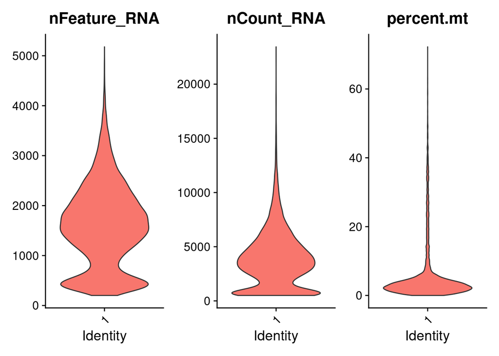

```r
VlnPlot(MmThyroid, features = c("nFeature_RNA", "nCount_RNA", "percent.mt"), ncol = 3,
        pt.size = 0, group.by = "orig.ident")
```

Remove cells that have high mitochondrial gene percentage or too many/too low total counts.

```r
MmThyroid <- subset(MmThyroid, subset = nFeature_RNA > 800 & nFeature_RNA < 5000
                    & percent.mt < 20 & nCount_RNA > 2000 & nCount_RNA < 20000)
```

**After filtration**

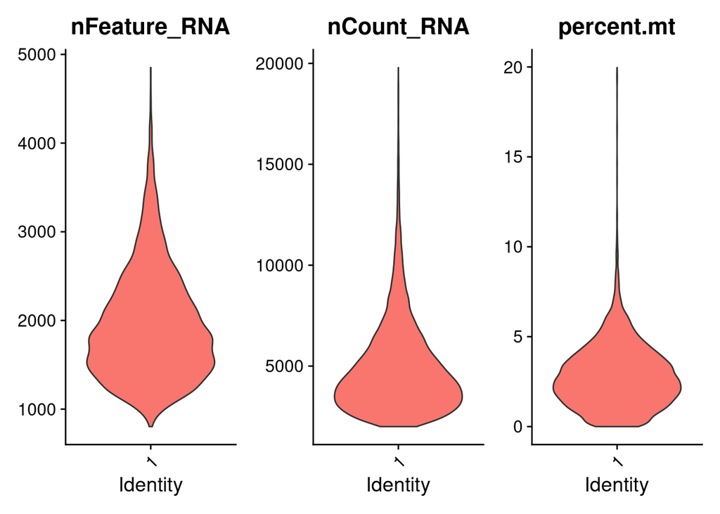

```r
VlnPlot(MmThyroid, features = c("nFeature_RNA", "nCount_RNA", "percent.mt"), ncol = 3,
        pt.size = 0, group.by = "orig.ident")
```

**Function to convert human genes to mouse**

```r
library(biomaRt)
human = useMart("ensembl", dataset = "hsapiens_gene_ensembl")
mouse = useMart("ensembl", dataset = "mmusculus_gene_ensembl")

human2ms <- function(human.genes){
  genesV2 = getLDS(attributes = c("hgnc_symbol"),
                   filters = "hgnc_symbol",
                   values = human.genes,
                   mart = human,
                   attributesL = c("mgi_symbol"),
                   martL = mouse, uniqueRows=F)
}
```

**Convert human cell cycle genes from Seurat to mouse orthologs**

```r
## Convert cc genes of seurat to mouse
# cc.genes.updated.2019
cc.genes.updated.2019_ms <- NULL

hs2ms_s.genes = human2ms(cc.genes.updated.2019$s.genes)
cc.genes.updated.2019_ms$s.genes <- unique(hs2ms_s.genes[, 2])

hs2ms_g2m.genes = human2ms(cc.genes.updated.2019$g2m.genes)
cc.genes.updated.2019_ms$g2m.genes <- unique(hs2ms_g2m.genes[, 2])
cc.genes.updated.2019_ms
```

```
## $s.genes
##  [1] "Gmnn"     "Rrm2"     "Mcm4"     "Ccne2"    "Casp8ap2" "Cdc45"
##  [7] "Dscc1"    "Fen1"     "Hells"    "Pola1"    "Mrpl36"   "Tyms"
## [13] "Slbp"     "Cenpu"    "Mcm6"     "Clspn"    "Rad51ap1" "Ubr7"
## [19] "Prim1"    "Mcm5"     "Gins2"    "Rad51"    "Msh2"     "E2f8"
## [25] "Usp1"     "Exo1"     "Wdr76"    "Ung"      "Rrm1"     "Uhrf1"
## [31] "Chaf1b"   "Nasp"     "Blm"      "Cdca7"    "Tipin"    "Cdc6"
## [37] "Polr1b"   "Dtl"      "Rfc2"     "Pcna"     "Mcm7"
##
## $g2m.genes
##  [1] "G2e3"    "Ect2"    "Cks2"    "Cdc25c"  "Ckap2"   "Dlgap5"  "Cenpa"
##  [8] "Kif11"   "Tacc3"   "Smc4"    "Rangap1" "Tubb4b"  "Anln"    "Hmgb2"
## [15] "Hmmr"    "Kif20b"  "Cdk1"    "Ttk"     "Ndc80"   "Ncapd2"  "Aurkb"
## [22] "Hjurp"   "Cbx5"    "Gas2l3"  "Cdc20"   "Top2a"   "Ckap5"   "Kif23"
## [29] "Cks1b"   "Tmpo"    "Cenpe"   "Ctcf"    "Cdca2"   "Cdca8"   "Nuf2"
## [36] "Psrc1"   "Kif2c"   "Lbr"     "Anp32e"  "Cdca3"   "Pimreg"  "Ccnb2"
## [43] "Gtse1"   "Nusap1"  "Cenpf"   "Mki67"   "Tpx2"    "Nek2"    "Aurka"
## [50] "Ube2c"   "Ckap2l"  "Birc5"   "Bub1"
```

**Cell cycle scoring**

```r
MmThyroid <- CellCycleScoring(MmThyroid, s.features = cc.genes.updated.2019_ms$s.genes,
                              g2m.features = cc.genes.updated.2019_ms$g2m.genes)
```

**Normalizing the data** Total count normalize and logaritmize the data. And identify highly variable genes. 2,000 features were selected for downstream PCA.

```r
MmThyroid <- SCTransform(MmThyroid,
                         vars.to.regress = c("nCount_RNA","percent.mt","S.Score", "G2M.Score"), variable.features.n = 2000)
```

## Dimensional Reduction

Reduce the dimensionality of the data.

```r
MmThyroid <- RunPCA(MmThyroid, features = VariableFeatures(object = MmThyroid))
```

```
## PC_ 1
## Positive:  Bsg, Mt1, Tg, Krt18, EGFP, Krt8, Ero1l, Klf6, Gdf15, Napsa
##     Timp3, Mt2, Atp1b1, Jun, Ndufa4l2, Dusp2, Krt19, Slc2a1, Espn, Asgr1
##     Ager, Rbp1, F3, Epcam, Rgcc, Mgarp, Sparc, Ces1d, Cdkn1a, Ctgf
## Negative:  Col3a1, Col1a1, Col1a2, Dcn, Vim, Cdkn1c, Ptn, Bgn, Dlk1, Igfbp7
##     Lum, Mgp, Igfbp4, Ifitm3, Col6a1, Lgals1, Itm2a, Lox, Lpl, Igfbp3
##     Sparcl1, Fbln1, Postn, Col5a2, Acta2, Prrx1, Tmem45a, Twist1, G0s2, Tagln
## PC_ 2
## Positive:  Sox11, Tubb2b, Mdk, Stmn1, Hsp90ab1, Map1b, Igfbp2, Eef1a1, Tuba1a, Tubb3
##     Id1, Slc2a3, Hmga2, Basp1, Id2, Id3, Npm1, En2, Stmn2, Bex2
##     Igfbpl1, Kif5c, Bex1, Rps20, Otx2, Hist3h2ba, Capn6, Eno3, Uchl1, Rtn1
## Negative:  Col1a1, Col3a1, Dcn, Col1a2, Mt1, Bsg, Tg, Igfbp7, Sparc, Bgn
##     Mgp, Rbp1, Ifitm3, Fth1, Lum, EGFP, Cebpb, Lpl, Ctsl, Lox
##     Col6a1, Ero1l, Hspa1a, Napsa, Igf1, Ndufa4l2, S100a6, G0s2, Sparcl1, Mt2
## PC_ 3
## Positive:  EGFP, Rbp1, Asgr1, Tg, Dusp2, Sparc, Atp1b1, Slc16a11, Cd24a, Mt1
##     Id3, Iyd, Napsa, Foxe1, Ptn, Ces1d, Prlr, Id1, Scg5, Mest
##     Ager, Serpinf1, Mdk, Cybrd1, Kcnk1, Cst6, C2cd4b, Hhex, Meg3, Map1b
## Negative:  Dppa5a, Krt18, Krt8, Ero1l, Lgals3, Slc2a1, Mkrn1, Ftl1-ps1, Hspb1, F3
##     Upp1, Pou5f1, Malat1, Zfp42, Krt19, Fabp3, Spp1, Ifitm1, Tdgf1, Trap1a
##     Apoe, S100a6, Cldn4, Utf1, Rhox5, Klf2, Nupr1, Sat1, Neat1, Cryab
## PC_ 4
## Positive:  Krt18, Krt8, Ero1l, Bsg, Slc2a1, Malat1, F3, Krt19, Col1a1, Col3a1
##     Col1a2, Cdkn1c, Ndrg1, Cldn4, Hsp90b1, Cdkn1a, Eif1, Hspa5, Fgfbp1, Nupr1
##     Cryab, Igfbp2, Krt7, Rpl13, P4ha2, P4hb, Cyr61, Col15a1, Klf6, Rps27a
## Negative:  Tmsb4x, Tyrobp, Fcer1g, Apoe, C1qb, C1qc, Cd14, Ctss, Pf4, Srgn
##     Ccl3, Fcgr3, Slfn2, Cxcl1, Cxcl2, Laptm5, C1qa, Ccl4, Lyz2, Fth1
##     Fcgr2b, Ms4a7, Csf1r, Bcl2a1b, Fxyd5, Ctsl, Clec4n, C3ar1, Ccrl2, Spi1
## PC_ 5
## Positive:  Dppa5a, Pou5f1, Zfp42, Mkrn1, Upp1, Fabp3, Tdgf1, Trap1a, Spp1, Utf1
##     Rhox5, Hsp90aa1, Tdh, Nanog, Gpx4, Klf2, Mt2, Mylpf, Sox2, Mt1
##     Chchd10, Ooep, Rbmxl2, Ifitm1, Fbxo15, Dppa3, Dnmt3l, Pmm1, L1td1, Mybl2
## Negative:  Krt18, Krt8, Tmsb4x, F3, Malat1, Krt19, Ero1l, Acta2, Pclaf, Lgals3
##     Tagln, Basp1, Fabp5, Krt7, Cyr61, Klf6, Actb, Bsg, Cryab, Actg1
##     Tpm1, Anxa1, Cldn4, Atf3, S100a6, Tuba1a, Tacstd2, Sox11, S100a14, Slc2a1
```

The contribution of single PCs to the total variance in the data. This gives us information about how many PCs we should consider in order to compute the neighborhood relations of cells. Here I chose to use the first 10 PCs based on the variety of clusters.

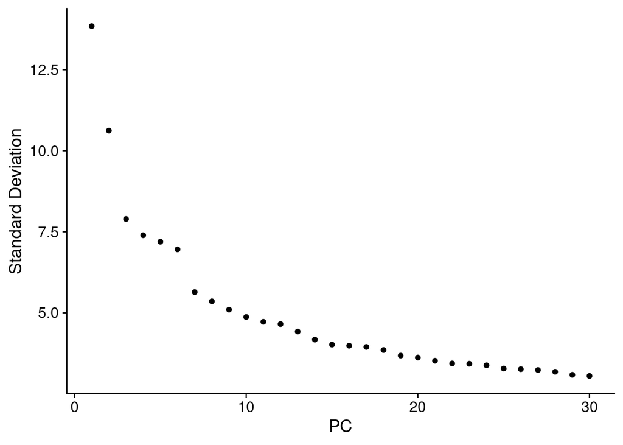

```r
# Determine the dimensionality of the dataset
ElbowPlot(MmThyroid, ndims=30)
```

```r
dims.use = 1:10
```

```r
# Run non-linear dimensional reduction
MmThyroid <- RunUMAP(MmThyroid, dims = dims.use)
# Cluster the cells
MmThyroid <- FindNeighbors(MmThyroid, dims = dims.use)
MmThyroid <- FindClusters(MmThyroid, resolution = 0.7)
```

**Visualize the clusters**

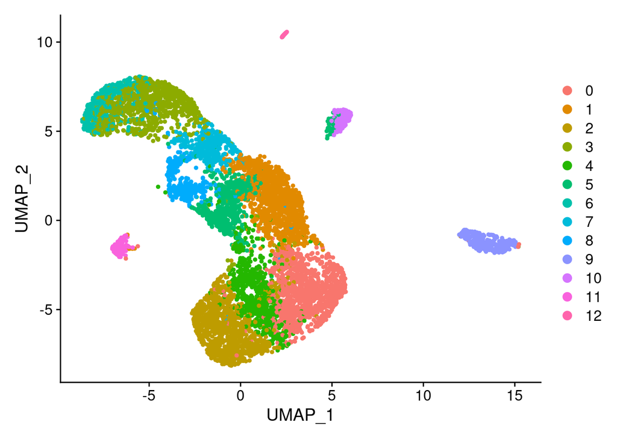

```r
DimPlot(MmThyroid, reduction = "umap", pt.size = 1, label = F, label.size = 6)
```

## Transfer cell types, umap coordinates and leiden clusters from scanpy

```r
metadata <- read.csv('/home/zebrafish/Elif/Jupyter-scripts/Costagliola lab/metadata.csv', row.names = 1)
```

**Transfer cell types**

```r
cells <- rownames(metadata)
cell_types <- metadata$cells
MmThyroid <- subset(MmThyroid, cells = cells)
MmThyroid <- AddMetaData(object = MmThyroid, metadata = cell_types, col.name = 'cells')
Idents(MmThyroid) <- MmThyroid$cells
```

**Transfer leiden clusters**

```r
leiden_clusters = metadata$leiden
MmThyroid <- AddMetaData(object = MmThyroid, metadata = leiden_clusters, col.name = 'leiden')
```

**Transfer UMAP coordinates**

```r
umap_1 = metadata$X_umap.0
umap_2 = metadata$X_umap.1
MmThyroid <- AddMetaData(object = MmThyroid, metadata = umap_1, col.name = 'UMAP_1')
MmThyroid <- AddMetaData(object = MmThyroid, metadata = umap_2, col.name = 'UMAP_2')

MmThyroid@reductions$umap@cell.embeddings[,1] <- MmThyroid@meta.data$UMAP_1
MmThyroid@reductions$umap@cell.embeddings[,2] <- MmThyroid@meta.data$UMAP_2
```

**Visualize the final plot**

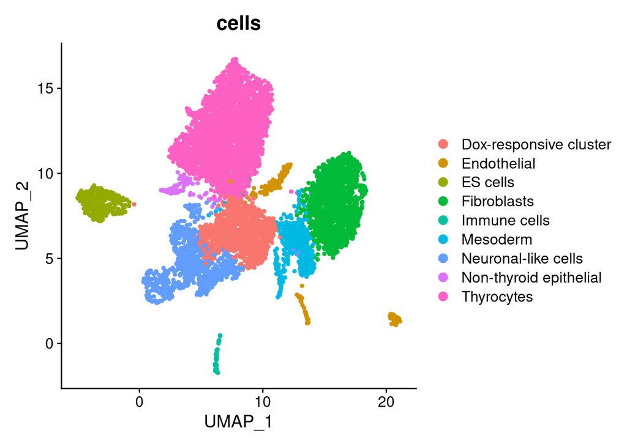

```r
DimPlot(MmThyroid, reduction = "umap", pt.size = 1, label = F, label.size = 6, group.by = c("cells"))
```

## Selecting mature and immature thyrocytes

**Mature cells expressing Slc5a5 and Tpo:**

```r
mature.cells <- which((as.numeric(MmThyroid@assays$SCT@data["Slc5a5",]) > 0.5 |
                        as.numeric(MmThyroid@assays$SCT@data["Tpo",]) > 0.5) &
                        (as.factor(MmThyroid@meta.data$cells) == 'Thyrocytes' |
                           as.factor(MmThyroid@meta.data$cells) == 'Dox-responsive cluster'))
```

**Immature cells expressing Tg, Slc5a5 and Tpo:**

```r
inter.cells <- which((as.numeric(MmThyroid@assays$SCT@data["Tg",]) >0.5 |
                       as.numeric(MmThyroid@assays$SCT@data["Slc5a5",]) > 0.5 |
                       as.numeric(MmThyroid@assays$SCT@data["Tpo",]) > 0.5) &
                       (as.factor(MmThyroid@meta.data$cells) == 'Thyrocytes' |
                          as.factor(MmThyroid@meta.data$cells) == 'Dox-responsive cluster'))
```

**Cells express early thyrocyte lineage markers: Nkx2-1, Pax8, Foxe1 and Hhex:**

```r
early.cells <- which((as.numeric(MmThyroid@assays$SCT@data["Nkx2-1",]) > 0.5 |
                       as.numeric(MmThyroid@assays$SCT@data["Pax8",]) > 0.5 |
                       as.numeric(MmThyroid@assays$SCT@data["Foxe1",]) > 0.5 |
                       as.numeric(MmThyroid@assays$SCT@data["Hhex",]) > 0.5 ) &
                       (as.factor(MmThyroid@meta.data$cells) == 'Thyrocytes' |
                          as.factor(MmThyroid@meta.data$cells) == 'Dox-responsive cluster'))
```

**Grouping mesodermal and fibroblast cells:**

```r
mes.cells <- which(as.factor(MmThyroid@meta.data$cells) == "Mesoderm" |
                     as.factor(MmThyroid@meta.data$cells) == "Fibroblasts")
```

**Adding cluster information to metadata:**

```r
MmThyroid@meta.data$cluster <- "Others"
MmThyroid@meta.data$cluster[mes.cells] <- "Mesoderm/Fibroblast"
MmThyroid@meta.data$cluster[early.cells] <- "Dox-responsive cluster"
MmThyroid@meta.data$cluster[inter.cells] <- "Immature Thyrocytes"
MmThyroid@meta.data$cluster[mature.cells] <- "Mature Thyrocytes"
```

**Visualize the cluster:**

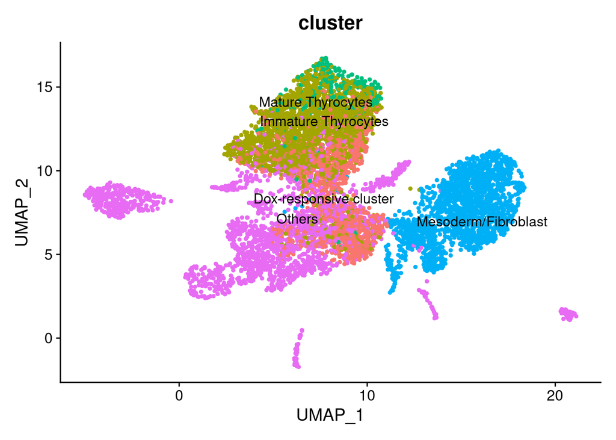

```r
DimPlot(MmThyroid, group.by = "cluster", label = TRUE, repel = TRUE, pt.size = 1)+ NoLegend()
```

Save the cell information for mature and immature thyrocyte:

```r
write.csv(MmThyroid@meta.data['cluster'], 'Mature_immature_early_thyrocytes.csv')
```

**Switch to Scanpy here**